# Data Science Project

## Team Yoda

### Yashwanth Reddy Dasari Reddy - 665044614

```python
import pandas as pd
from scipy import stats
import seaborn as sns
import matplotlib.pyplot as plt
from itertools import cycle
```

```python
data = pd.read_csv('spg.csv')
```

```python
data.head()
```

|  | temperature_2_m_above_gnd | relative_humidity_2_m_above_gnd | mean_sea_level_pressure_MSL | total_precipitation_sfc | snowfall_amount_sfc | total_cloud_cover_sfc | high_cloud_cover_high_cld_lay | medium_cloud_cover_mid_cld_lay | low_cloud_cover_low_cld_lay | shortwave_radiation_backwards_sfc | ... | wind_direction_10_m_above_gnd | wind_speed_80_m_above_gnd | wind_direction_80_m_above_gnd | wind_speed_900_mb | wind_direction_900_mb | wind_gust_10_m_above_gnd | angle_of_incidence | zenith | azimuth | generated_power_kw |
| --- | --- | --- | --- | --- | --- | --- | --- | --- | --- | --- | --- | --- | --- | --- | --- | --- | --- | --- | --- | --- | --- |
| 0 | 2.17 | 31 | 1035.0 | 0.0 | 0.0 | 0.0 | 0 | 0 | 0 | 0.00 | ... | 312.71 | 9.36 | 22.62 | 6.62 | 337.62 | 24.48 | 58.753108 | 83.237322 | 128.33543 | 454.10095 |
| 1 | 2.31 | 27 | 1035.1 | 0.0 | 0.0 | 0.0 | 0 | 0 | 0 | 1.78 | ... | 294.78 | 5.99 | 32.74 | 4.61 | 321.34 | 21.96 | 45.408585 | 75.143041 | 139.65530 | 1411.99940 |
| 2 | 3.65 | 33 | 1035.4 | 0.0 | 0.0 | 0.0 | 0 | 0 | 0 | 108.58 | ... | 270.00 | 3.89 | 56.31 | 3.76 | 286.70 | 14.04 | 32.848282 | 68.820648 | 152.53769 | 2214.84930 |
| 3 | 5.82 | 30 | 1035.4 | 0.0 | 0.0 | 0.0 | 0 | 0 | 0 | 258.10 | ... | 323.13 | 3.55 | 23.96 | 3.08 | 339.44 | 19.80 | 22.699288 | 64.883536 | 166.90159 | 2527.60920 |
| 4 | 7.73 | 27 | 1034.4 | 0.0 | 0.0 | 0.0 | 0 | 0 | 0 | 375.58 | ... | 10.01 | 6.76 | 25.20 | 6.62 | 22.38 | 16.56 | 19.199908 | 63.795208 | 182.13526 | 2640.20340 |

5 rows × 21 columns

```python
data.info()
```

```
<class 'pandas.core.frame.DataFrame'>
RangeIndex: 4213 entries, 0 to 4212
Data columns (total 21 columns):
 #   Column                             Non-Null Count  Dtype
---  ------                             --------------  -----
 0   temperature_2_m_above_gnd          4213 non-null   float64
 1   relative_humidity_2_m_above_gnd    4213 non-null   int64
 2   mean_sea_level_pressure_MSL        4213 non-null   float64
 3   total_precipitation_sfc            4213 non-null   float64
 4   snowfall_amount_sfc                4213 non-null   float64
 5   total_cloud_cover_sfc              4213 non-null   float64
 6   high_cloud_cover_high_cld_lay      4213 non-null   int64
 7   medium_cloud_cover_mid_cld_lay     4213 non-null   int64
 8   low_cloud_cover_low_cld_lay        4213 non-null   int64
 9   shortwave_radiation_backwards_sfc  4213 non-null   float64
 10  wind_speed_10_m_above_gnd          4213 non-null   float64
 11  wind_direction_10_m_above_gnd      4213 non-null   float64
 12  wind_speed_80_m_above_gnd          4213 non-null   float64
 13  wind_direction_80_m_above_gnd      4213 non-null   float64
 14  wind_speed_900_mb                  4213 non-null   float64
 15  wind_direction_900_mb              4213 non-null   float64
 16  wind_gust_10_m_above_gnd           4213 non-null   float64
 17  angle_of_incidence                 4213 non-null   float64
 18  zenith                             4213 non-null   float64
 19  azimuth                            4213 non-null   float64
 20  generated_power_kw                 4213 non-null   float64
dtypes: float64(17), int64(4)
memory usage: 691.3 KB
```

```python
# Perform basic statistical analysis
statistics = data.describe()

# Check for skewness in your data
skewness = data.skew()

# Check for kurtosis in your data
kurtosis = data.kurtosis()

# Check for missing values
missing_values = data.isnull().sum()

# Correlation matrix to understand the relationships
correlation_matrix = data.corr()


# Output the basic statistics
print(statistics)
print("\nSkewness:\n", skewness)
print("\nKurtosis:\n", kurtosis)
print("\nMissing Values:\n", missing_values)
print("\nCorrelation Matrix:\n", correlation_matrix)

# Handling missing values (imputation, dropping rows/columns, etc.) would come next if required.
```

```
       temperature_2_m_above_gnd  relative_humidity_2_m_above_gnd  \
count                4213.000000                      4213.000000
mean                   15.068111                        51.361025
std                     8.853677                        23.525864
min                    -5.350000                         7.000000
25%                     8.390000                        32.000000
50%                    14.750000                        48.000000
75%                    21.290000                        70.000000
max                    34.900000                       100.000000

       mean_sea_level_pressure_MSL  total_precipitation_sfc  \
count                  4213.000000              4213.000000
mean                   1019.337812                 0.031759
std                       7.022867                 0.170212
min                     997.500000                 0.000000
25%                    1014.500000                 0.000000
50%                    1018.100000                 0.000000
75%                    1023.600000                 0.000000
max                    1046.800000                 3.200000

       snowfall_amount_sfc  total_cloud_cover_sfc  \
count          4213.000000            4213.000000
mean              0.002808              34.056990
std               0.038015              42.843638
min               0.000000               0.000000
25%               0.000000               0.000000
50%               0.000000               8.700000
75%               0.000000             100.000000
max               1.680000             100.000000

       high_cloud_cover_high_cld_lay  medium_cloud_cover_mid_cld_lay  \
count                    4213.000000                     4213.000000
mean                       14.458818                       20.023499
std                        30.711707                       36.387948
min                         0.000000                        0.000000
25%                         0.000000                        0.000000
50%                         0.000000                        0.000000
75%                         9.000000                       10.000000
max                       100.000000                      100.000000

```

[output cut: 479 more lines]

```
low_cloud_cover_low_cld_lay                 -0.288066
shortwave_radiation_backwards_sfc            0.556148
wind_speed_10_m_above_gnd                   -0.083043
wind_direction_10_m_above_gnd               -0.073257
wind_speed_80_m_above_gnd                   -0.157899
wind_direction_80_m_above_gnd               -0.069941
wind_speed_900_mb                           -0.107615
wind_direction_900_mb                       -0.077435
wind_gust_10_m_above_gnd                    -0.122808
angle_of_incidence                          -0.646537
zenith                                      -0.649991
azimuth                                     -0.061184
generated_power_kw                           1.000000

[21 rows x 21 columns]
```

# Visualization : Histogram

The dataset's histograms reveal diverse distributions across meteorological and power generation variables. Temperature and pressure display normal distributions, while precipitation and power generation are right-skewed. These patterns inform the selection of regression models and highlight the need for data transformation in predictive analytics, crucial for optimizing resource allocation and strategic decision-making.

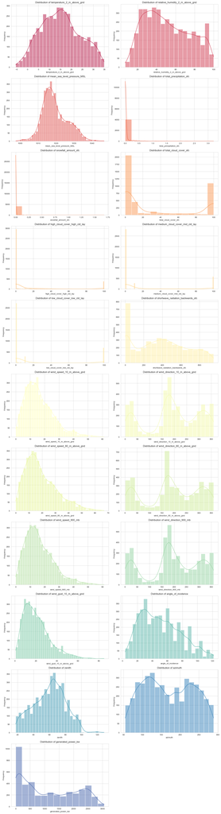

```python
import warnings
warnings.filterwarnings("ignore")

# Set the aesthetic style of the plots
sns.set_style("whitegrid")

# Suppress warnings
plt.rcParams.update({'figure.max_open_warning': 0})

# Select only numeric columns for plotting
numeric_cols = data.select_dtypes(include=['float64', 'int64']).columns.tolist()

# Define a list of colors for the plots
colors = cycle(sns.color_palette("Spectral", n_colors=len(numeric_cols)))

# Setup for 2 plots per row
cols_per_row = 2
num_rows = len(numeric_cols) // cols_per_row + (len(numeric_cols) % cols_per_row > 0)
fig, axes = plt.subplots(num_rows, cols_per_row, figsize=(15, num_rows * 5))

# Generate histograms with KDE for each numeric column
for i, col in enumerate(numeric_cols):
    ax = axes[i // cols_per_row, i % cols_per_row]
    color = next(colors)
    sns.histplot(data[col], kde=True, color=color, ax=ax)
    ax.set_title(f'Distribution of {col}')
    ax.set_xlabel(col)
    ax.set_ylabel('Frequency')

# Remove any empty subplots if the number of plots is not even
if len(numeric_cols) % cols_per_row != 0:
    fig.delaxes(axes[-1, -1])

plt.tight_layout()
plt.show()
```

### Analysis and Decision on Model Selection

**Normal and Skewed Distributions:** Variables like temperature, pressure, and zenith angles appear to follow a normal distribution, suggesting that simple linear regression could effectively model the relationship between these variables and outcomes like energy consumption or generation. Other variables, such as precipitation, snowfall, and generated power, show right-skewed distributions. For these, transformations (like log transformation) or non-linear models may be more appropriate.

**Seasonal Patterns:** The bimodal distributions seen in variables like shortwave radiation and azimuth suggest seasonal patterns. For such cases, including seasonal cycles as part of the regression model, or using time series analysis, can improve the accuracy of predictions.

**Variable Relationships:** Understanding how these variables interact with each other is crucial. For example, solar power generation would be closely tied to shortwave radiation and cloud cover. Multivariate regression can help quantify these relationships and predict outcomes based on several input variables.

**Anomalies and Outliers:** Some histograms have bars that are separated from the main body of the graph, which could indicate outliers or anomalies in the data. It's important to determine whether to include these in your regression analysis or to treat them separately.

**Potential for Predictive Models:** With variables like wind speed and direction at various atmospheric levels, predictive models can be built to forecast wind power generation. Similarly, solar power generation could be predicted with variables like shortwave radiation, zenith, and azimuth.

**Model Selection:** Based on the distribution of our data, different regression algorithms could be applied. For normally distributed data, linear regression or Gaussian processes might be suitable. For non-linear relationships, algorithms like polynomial regression, support vector machines with non-linear kernels, or neural networks might be more effective.

### In terms of actions:

**Optimization:** We can use the regression models to optimize for the variables that most influence renewable energy production, like adjusting the angles of solar panels according to the predicted solar position (zenith and azimuth) or positioning wind turbines based on predicted wind patterns.

**Forecasting:** Develop forecasting models for weather-dependent variables to predict future trends and prepare accordingly, which is crucial for sectors like agriculture, energy, and logistics.

**Risk Management:** For variables with high variability and unpredictability (like precipitation), you might focus on risk management strategies to mitigate potential negative impacts, such as flood or drought preparation plans.

**Policy Making:** For broader applications, such as urban planning or energy policy, this data can inform decisions on where to invest in renewable energy infrastructure or how to design cities to be more resilient against climate variability.

# ML Analysis

```python
from sklearn.model_selection import train_test_split
from sklearn.ensemble import GradientBoostingRegressor
from xgboost import XGBRegressor
from sklearn.metrics import mean_squared_error, r2_score

# Assuming 'data' is your DataFrame and 'generated_power_kw' is the target variable
X = data.drop('generated_power_kw', axis=1)  # Features
y = data['generated_power_kw']  # Target

# Split the data into training and testing sets
X_train, X_test, y_train, y_test = train_test_split(X, y, test_size=0.2, random_state=42)

# Initialize and train the GradientBoostingRegressor model
gbm = GradientBoostingRegressor(n_estimators=100, learning_rate=0.1, max_depth=3, random_state=42)
gbm.fit(X_train, y_train)

# Initialize and train the XGBRegressor model
xgb = XGBRegressor(n_estimators=100, learning_rate=0.1, max_depth=3, random_state=42)
xgb.fit(X_train, y_train)

# Predict with both models
y_pred_gbm = gbm.predict(X_test)
y_pred_xgb = xgb.predict(X_test)

# Calculate metrics for both models
mse_gbm = mean_squared_error(y_test, y_pred_gbm)
r2_gbm = r2_score(y_test, y_pred_gbm)
rmse_gbm = mean_squared_error(y_test, y_pred_gbm, squared=False)

mse_xgb = mean_squared_error(y_test, y_pred_xgb)
r2_xgb = r2_score(y_test, y_pred_xgb)
rmse_xgb = mean_squared_error(y_test, y_pred_xgb, squared=False)

# Compare the metrics
print("GradientBoostingRegressor:")
print(f'Mean Squared Error: {mse_gbm}')
print(f'R-squared: {r2_gbm}')
print(f'RMSE: {rmse_gbm}')

print("\nXGBRegressor:")
print(f'Mean Squared Error: {mse_xgb}')
print(f'R-squared: {r2_xgb}')
print(f'RMSE: {rmse_xgb}')
```

```
GradientBoostingRegressor:
Mean Squared Error: 180797.22558519602
R-squared: 0.8020750990472814
RMSE: 425.2025700594906

XGBRegressor:
Mean Squared Error: 179288.61283240584
R-squared: 0.8037266289792565
RMSE: 423.42486090498494
```

# Visualisations and Comparision Between GBM and XG Boost

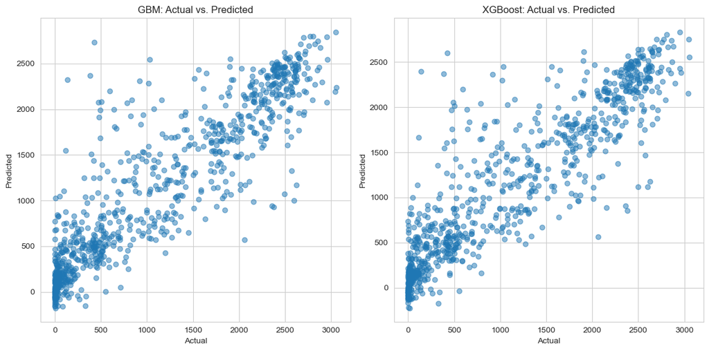

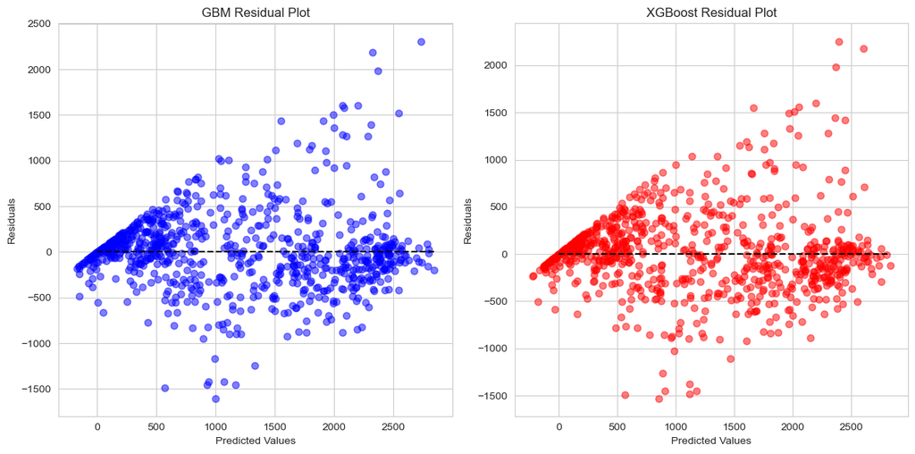

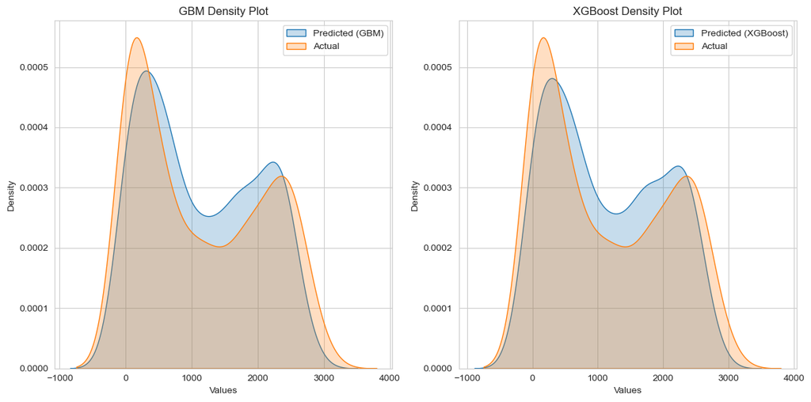

```python
import matplotlib.pyplot as plt
import seaborn as sns
import warnings
warnings.filterwarnings("ignore")

# Predict with both GBM and XGBoost models
y_pred_gbm = gbm.predict(X_test)
y_pred_xgb = xgb.predict(X_test)

# Create scatter plots to compare actual vs. predicted values for both models
plt.figure(figsize=(12, 6))
plt.subplot(1, 2, 1)
plt.scatter(y_test, y_pred_gbm, alpha=0.5)
plt.title('GBM: Actual vs. Predicted')
plt.xlabel('Actual')
plt.ylabel('Predicted')

plt.subplot(1, 2, 2)
plt.scatter(y_test, y_pred_xgb, alpha=0.5)
plt.title('XGBoost: Actual vs. Predicted')
plt.xlabel('Actual')
plt.ylabel('Predicted')

plt.tight_layout()
plt.show()

# Create residual plots for both models
plt.figure(figsize=(12, 6))
plt.subplot(1, 2, 1)
plt.scatter(y_pred_gbm, y_pred_gbm - y_test, c='b', s=40, alpha=0.5)
plt.hlines(y=0, xmin=0, xmax=max(y_pred_gbm), colors='k', linestyles='dashed')
plt.title('GBM Residual Plot')
plt.xlabel('Predicted Values')
plt.ylabel('Residuals')

plt.subplot(1, 2, 2)
plt.scatter(y_pred_xgb, y_pred_xgb - y_test, c='r', s=40, alpha=0.5)
plt.hlines(y=0, xmin=0, xmax=max(y_pred_xgb), colors='k', linestyles='dashed')
plt.title('XGBoost Residual Plot')
plt.xlabel('Predicted Values')
plt.ylabel('Residuals')

plt.tight_layout()
plt.show()

# Create density plots for both models
plt.figure(figsize=(12, 6))
plt.subplot(1, 2, 1)
sns.kdeplot(y_pred_gbm, label='Predicted (GBM)', shade=True)
sns.kdeplot(y_test, label='Actual', shade=True)
plt.title('GBM Density Plot')
plt.xlabel('Values')
plt.ylabel('Density')
plt.legend()

plt.subplot(1, 2, 2)
sns.kdeplot(y_pred_xgb, label='Predicted (XGBoost)', shade=True)
sns.kdeplot(y_test, label='Actual', shade=True)
plt.title('XGBoost Density Plot')
plt.xlabel('Values')
plt.ylabel('Density')
plt.legend()

plt.tight_layout()
plt.show()
```

## Model Performance Analysis

### Overview

The performance of two advanced ensemble learning models, the Gradient Boosting Machine (GBM) and XGBoost, was evaluated on a solar energy power generation dataset. The assessment was conducted using residual plots, density plots, and quantitative metrics such as Mean Squared Error (MSE), R-squared, and Root Mean Squared Error (RMSE).

### Quantitative Metrics

**GBM:** Exhibited an MSE of 180797.22, an R-squared of 0.802, and an RMSE of 425.20.

**XGBoost:** Showed a slightly improved performance with an MSE of 179288.61, an R-squared of 0.803, and an RMSE of 423.42.

The R-squared values for both models suggest that approximately 80% of the variability in solar power generation can be explained by the predictive features utilized in the models. The RMSE values, while relatively close between the two models, indicate the average deviation of the predicted values from the actual generated power.

### Residual Plot Analysis

**GBM Residuals:** The residuals displayed a pattern indicative of overestimation, particularly for mid-range predicted values. The lack of symmetry around the zero line in the residuals suggests systematic bias in this range.

### Conclusions and Recommendations

While both models perform robustly for a significant portion of the data, there are clear opportunities for improvement, especially in accurately predicting higher values of power generation. To enhance model performance, the following steps are recommended:

**Data Transformation:** To address the non-uniform variance and the skewness in residuals, data transformation techniques may be beneficial. Hyperparameter Optimization: Fine-tuning the models' hyperparameters through methods like grid search or random search could yield improvements in prediction accuracy.

**Feature Engineering:** Developing additional features or transforming existing ones could help capture the underlying patterns in the data more effectively.

**Error Analysis:** A deeper dive into the specific areas where the models are underperforming could lead to targeted improvements.

**Alternative Modeling Techniques:** Investigating other regression techniques may offer improvements or insights that the current models do not capture.

**Regularization Strategies:** Implementing regularization might help mitigate overfitting, particularly for the XGBoost model.